# Independent T-Test Demo Fall 2024

Brady C. Jackson

2024/10/01

```r
library(psych)
library(jmv)
```

```r
library(ggplot2)
library(dplyr)
library(magrittr)
```

*Independent T Test Example 1* Alarafi & Song (2024) conducted a recent study comparing online distance learning and traditional in-person education at King Saud University in Saudi Arabia, with a focus on understanding how different educational modalities affect student achievement. By analyzing the final test scores of freshman students in five core courses over the 2020 (in-person) and 2021 (online) academic years, the research provides empirical insights into the efficacy of online versus traditional education.

RQ: Does learning modality differentially impact achievement?

Model Learning Modality (Online v. InPerson) –> Achievement

Statistical Mode Achievement = Modality + Error

**SET UP**

```r
#read in the data
dat_ach <- read.csv("independent ttest demo.ach.csv")
colnames(dat_ach) <- tolower(colnames(dat_ach))
```

```r
# The "Modality" variable was entered as a character so we need to convert it to
# a factor
dat_ach$modality <- as.factor(dat_ach$modality)
```

**DESCRIPTIVES**

```
##
##  DESCRIPTIVES
##
##  Descriptives
##  ──────────────────────────────────────────────────
##                           modality    ach
##  ──────────────────────────────────────────────────
##    N                          5191           5191
##    Missing                       0              0
##    Mean                                  37.55735
##    Std. error mean                      0.1217974
##    Median                                37.69000
##    Standard deviation                    8.775330
##    Minimum                              0.4500000
##    Maximum                               75.32000
##    Skewness                           -0.04395494
##    Std. error skewness                 0.03398793
##    Kurtosis                             0.1140904
##    Std. error kurtosis                 0.06796278
##  ──────────────────────────────────────────────────
##
##
##  FREQUENCIES
##
##  Frequencies of modality
##  ────────────────────────────────────────────────────
##    modality    Counts    % of Total    Cumulative %
##  ────────────────────────────────────────────────────
##    InPerson      2663      51.30033        51.30033
##    Online        2528      48.69967       100.00000
##  ────────────────────────────────────────────────────
```

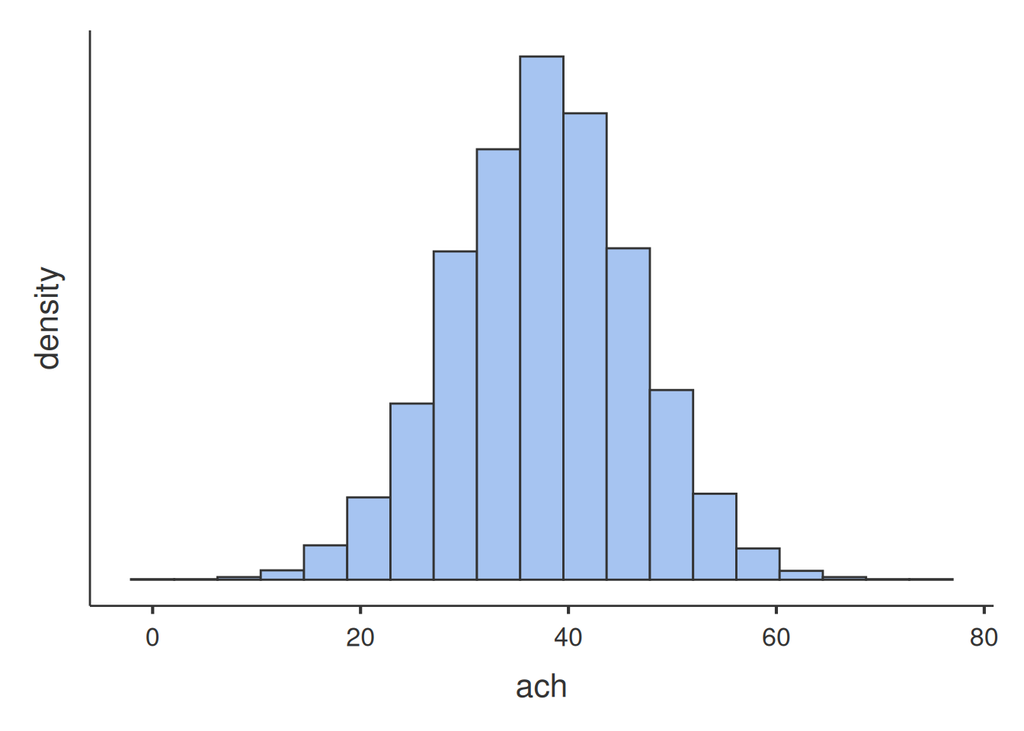

```r
# Get descriptive statistics for the entire sample
desc_ach <- jmv::descriptives(
                                dat_ach, vars = c('modality', 'ach'),
                                hist = TRUE,
                                freq = TRUE,
                                sd = TRUE,
                                se = TRUE,
                                skew = TRUE,
                                kurt = TRUE
                             )

desc_ach
```

```
##
##  DESCRIPTIVES
##
##  Descriptives
##  ─────────────────────────────────────────────────
##                           modality    ach
##  ─────────────────────────────────────────────────
##    N                      InPerson          2663
##                           Online            2528
##    Missing                InPerson             0
##                           Online               0
##    Mean                   InPerson      39.48499
##                           Online        35.52677
##    Std. error mean        InPerson     0.1563594
##                           Online       0.1795880
##    Median                 InPerson      39.44000
##                           Online        35.38000
##    Standard deviation     InPerson      8.068814
##                           Online        9.029543
##    Minimum                InPerson      7.510000
##                           Online       0.4500000
##    Maximum                InPerson      75.32000
##                           Online        65.45000
##    Skewness               InPerson    0.01203495
##                           Online      0.04520320
##    Std. error skewness    InPerson    0.04744010
##                           Online      0.04868886
##    Kurtosis               InPerson     0.2461447
##                           Online      0.02247072
##    Std. error kurtosis    InPerson    0.09484469
##                           Online      0.09733933
##  ─────────────────────────────────────────────────
```

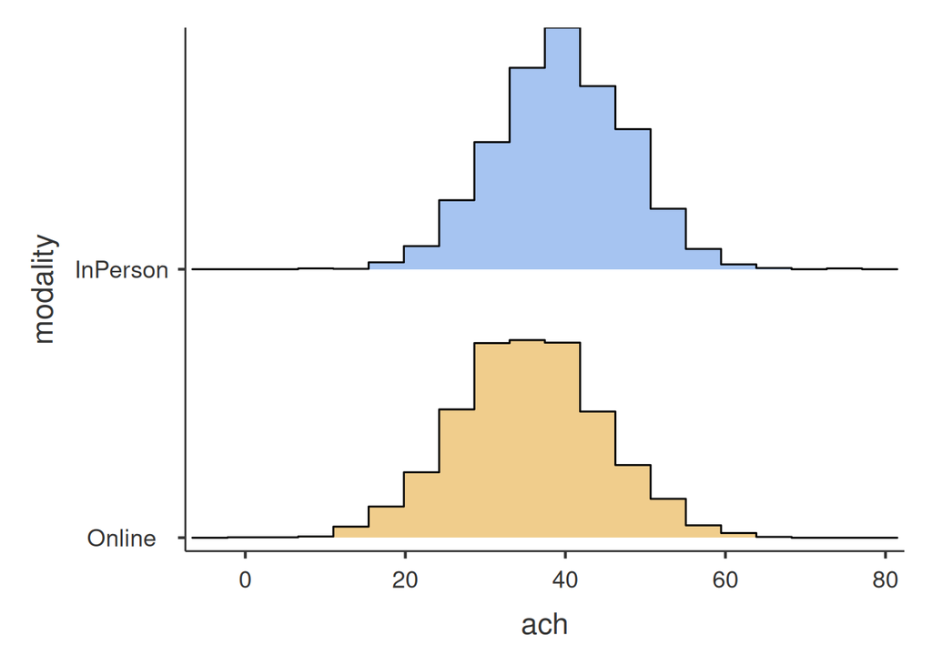

```r
# Get descriptive statistics for eachmac or pc group
groupdesc_ach <- jmv::descriptives(
                                    dat_ach, vars = c('ach'), splitBy='modality',
                                    hist = TRUE,
                                    sd = TRUE,
                                    se = TRUE,
                                    skew = TRUE,
                                    kurt = TRUE
                                   )

groupdesc_ach
```

**VISUALIZE YOUR DATA**

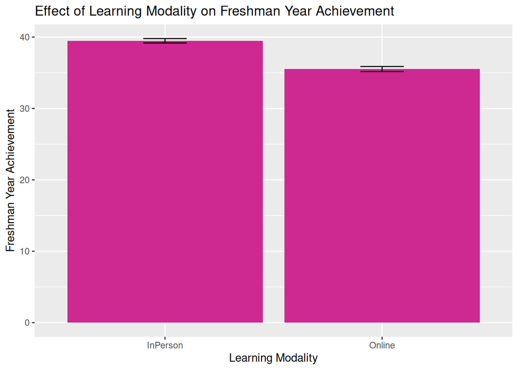

```r
#creating a bar graph
# Creates bar graph object
achbar <- ggplot2::ggplot(dat_ach, aes(modality, ach))

# Annotates bar graph figure. Read ggplot2 docs to understand why the + syntax
# is the preferred syntax here (or maybe it's not, who knows.)
achbar +
    stat_summary(fun = mean, geom = "bar", position = "dodge", fill="maroon3") +
    stat_summary(
                  fun.data = mean_cl_normal,
                  geom = "errorbar",
                  position = position_dodge(width = 0.90),
                  width = 0.2
                 ) +
    labs(x = "Learning Modality", y = "Freshman Year Achievement") +
    ggtitle('Effect of Learning Modality on Freshman Year Achievement')
```

**T TEST**

```r
#vars = outcome variable
# While this makes it easy to run independent sample T-tests, you need to know
# that you can explain (conceptually) EVERY number in the output.
# i.e. test questions will ask you to explain weird numbers in output
jmv::ttestIS(
                data = dat_ach,           # Dataframe to analyze
                vars = 'ach',             # Outcome variable
                group = 'modality',       # Dependent variable to group by
                effectSize = TRUE,
                ci = TRUE,
                meanDiff = TRUE,
                desc = TRUE               # Reprint descriptives because we're too lazy to scroll up
             )
```

```
##
##  INDEPENDENT SAMPLES T-TEST
##
##  Independent Samples T-Test
##  ──────────────────────────────────────────────────────────────────────────────────────────────────────────────────────────────────────────────────────
##                          Statistic     df          p             Mean difference    SE difference    Lower       Upper                    Effect Size
##  ──────────────────────────────────────────────────────────────────────────────────────────────────────────────────────────────────────────────────────
##    ach    Student's t    16.67146 ᵃ    5189.000    < .0000001           3.958222        0.2374250    3.492769    4.423675    Cohen's d      0.4629404
##  ──────────────────────────────────────────────────────────────────────────────────────────────────────────────────────────────────────────────────────
##    Note. Hₐ μ <sub>InPerson</sub> ≠ μ <sub>Online</sub>
##    ᵃ Levene's test is significant (p < .05), suggesting a violation of the assumption of equal variances
##
##
##  Group Descriptives
##  ────────────────────────────────────────────────────────────────────────────
##           Group       N       Mean        Median      SD          SE
##  ────────────────────────────────────────────────────────────────────────────
##    ach    InPerson    2663    39.48499    39.44000    8.068814    0.1563594
##           Online      2528    35.52677    35.38000    9.029543    0.1795880
##  ────────────────────────────────────────────────────────────────────────────
```

*APA WRITE UP* An independent t-test confirmed that students who took their Freshman year  
courses in-person (*M* = 39.49) had significantly higher levels of achievement  
than those in the online cohort (*M* = 35.53), *t*(5189) = 16.67, *p* < .001, *d* = 0.46, 95% CI [3.49,4.42].  
Learning modality had a moderate effect on achievement, the mean performance  
scores for in-person students were just under a half a standard deviation above  
those of online students.

*Independent T Test Example 2* Music performance anxiety has been known to impact musicians abilities to perform and find success in their industry. Martin-Gagnon and Creech (2019) sought to determine if the setting in which a jazz musician was playing, solo or in an ensemble, made a difference in the anxiety they experienced prior to performing.They collected data from 76 performers who played primarily solo or primarily in ensembles, and collected data regarding their music performance anxiety.

RQ: Does the setting a musician plays music in predict anxiety before performing?

Model: Setting (solo, ensemble) –> music performance anxiety Stats model anxiety = setting + error

**SET UP**

```r
#read in the data
dat_jazz <- read.csv("independent ttest demo.jazz.csv")

# The "Group" variable was entered as an integer so we need to convert it to a factor
dat_jazz$setting <- as.factor(dat_jazz$setting)
```

**DESCRIPTIVES**

```
##
##  DESCRIPTIVES
##
##  Descriptives
##  ─────────────────────────────────────
##                           anxiety
##  ─────────────────────────────────────
##    N                              76
##    Missing                         0
##    Mean                     114.5350
##    Std. error mean          3.162983
##    Median                   116.5271
##    Standard deviation       27.57425
##    Minimum                  52.91617
##    Maximum                  182.2199
##    Skewness               -0.1328006
##    Std. error skewness     0.2756375
##    Kurtosis               -0.2141592
##    Std. error kurtosis     0.5448041
##  ─────────────────────────────────────
```

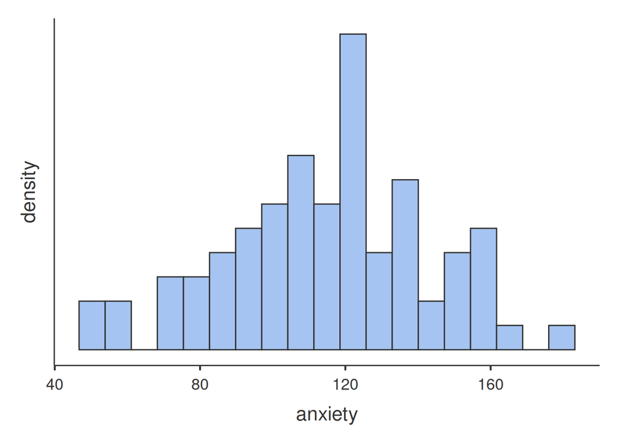

```r
# Get descriptive statistics for the entire sample
desc_jazz <- descriptives(dat_jazz, vars = c('anxiety'), hist = TRUE, sd = TRUE, se = TRUE, skew = TRUE, kurt = TRUE)
desc_jazz
```

```
##
##  DESCRIPTIVES
##
##  Descriptives
##  ──────────────────────────────────────────────────
##                           setting     anxiety
##  ──────────────────────────────────────────────────
##    N                      ensemble             38
##                           solo                 38
##    Missing                ensemble              0
##                           solo                  0
##    Mean                   ensemble       117.9200
##                           solo           111.1500
##    Std. error mean        ensemble       4.899087
##                           solo           3.992269
##    Median                 ensemble       121.4372
##                           solo           112.1983
##    Standard deviation     ensemble       30.20000
##                           solo           24.61000
##    Minimum                ensemble       53.20148
##                           solo           52.91617
##    Maximum                ensemble       182.2199
##                           solo           157.8760
##    Skewness               ensemble     -0.2682309
##                           solo         -0.1138360
##    Std. error skewness    ensemble      0.3828184
##                           solo          0.3828184
##    Kurtosis               ensemble     -0.2485584
##                           solo        -0.09620294
##    Std. error kurtosis    ensemble      0.7497004
##                           solo          0.7497004
##  ──────────────────────────────────────────────────
```

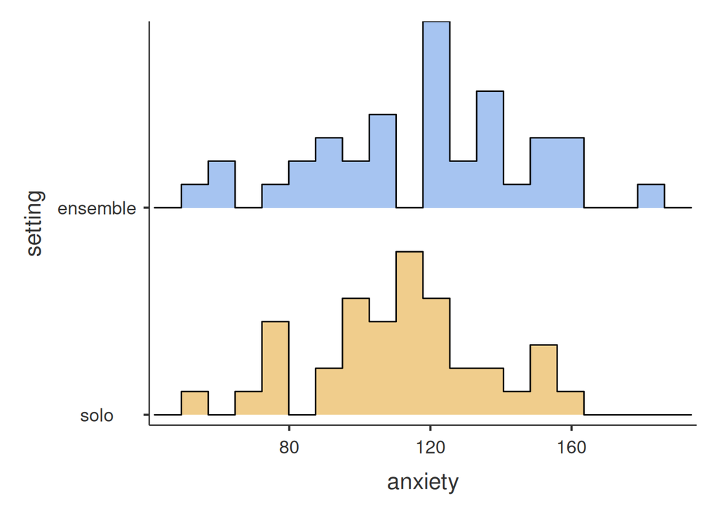

```r
# Get descriptive statistics for each group
groupdesc_jazz <- descriptives(dat_jazz, vars = c('anxiety'), splitBy='setting', hist = TRUE, sd = TRUE, se = TRUE, skew = TRUE, kurt = TRUE)
groupdesc_jazz
```

**VISUALIZE YOUR DATA**

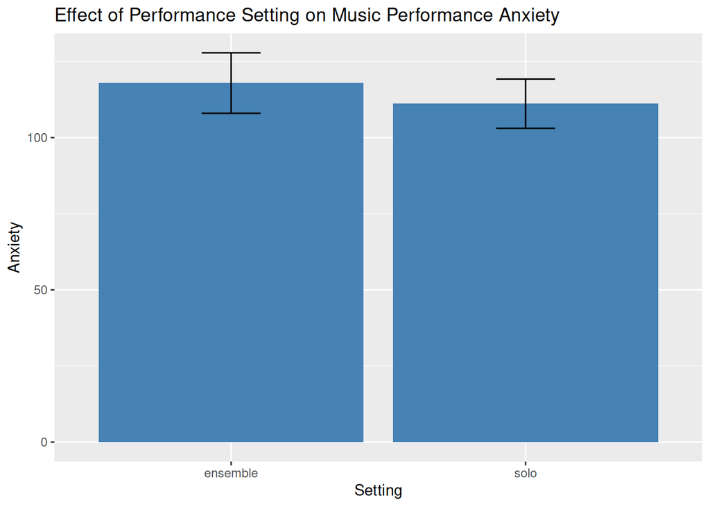

```r
#creating a bar graph (you can forget the really complicated code you used in One Way ANOVA, it i simplified for you below.
jazzbar <- ggplot(dat_jazz, aes(setting, anxiety))

jazzbar + stat_summary(fun = mean, geom = "bar", position = "dodge", fill="steelblue") + stat_summary(fun.data = mean_cl_normal, geom = "errorbar", position = position_dodge(width = 0.90), width = 0.2) + labs(x = "Setting", y = "Anxiety") + ggtitle('Effect of Performance Setting on Music Performance Anxiety')
```

**T TEST**

```r
ttestIS(data = dat_jazz, vars = 'anxiety', group = 'setting', effectSize = TRUE, ci = TRUE, meanDiff = TRUE, ciES =, desc = TRUE)
```

```
##
##  INDEPENDENT SAMPLES T-TEST
##
##  Independent Samples T-Test
##  ─────────────────────────────────────────────────────────────────────────────────────────────────────────────────────────────────────────────────────────
##                              Statistic    df          p            Mean difference    SE difference    Lower        Upper                    Effect Size
##  ─────────────────────────────────────────────────────────────────────────────────────────────────────────────────────────────────────────────────────────
##    anxiety    Student's t     1.071245    74.00000    0.2875409           6.770000         6.319752    -5.822381    19.36238    Cohen's d      0.2457604
##  ─────────────────────────────────────────────────────────────────────────────────────────────────────────────────────────────────────────────────────────
##    Note. Hₐ μ <sub>ensemble</sub> ≠ μ <sub>solo</sub>
##
##
##  Group Descriptives
##  ─────────────────────────────────────────────────────────────────────────────
##               Group       N     Mean        Median      SD          SE
##  ─────────────────────────────────────────────────────────────────────────────
##    anxiety    ensemble    38    117.9200    121.4372    30.20000    4.899087
##               solo        38    111.1500    112.1983    24.61000    3.992269
##  ─────────────────────────────────────────────────────────────────────────────
```

*APA WRITE UP* An independent t-test confirmed that musicians who play solo (*M* = 111.15) do not have significantly different anxiety than those who play in ensembles (*M* = 117.92), *t*(74) = 1.07, *p* = .288, *d* = 0.25, 95% CI[-5.822,19.36]. There was a small effect, with the mean anxiety of ensemble musicians only .25 of a standard deviation above solo musicians.

*Intependent T Test Example 3* Leadership qualities were explored in 362 college seniors who were surveyed regarding several variables, including their leader self-efficacy (confidence in leader abilities). You, the researcher, are wondering if taking the Intro to Leadership course, which over half of the students in the sample were enrolled in, has any impact on their leader self-efficacy.

RQ: Does taking the Intro to Leadership class predict higher Leader Self-Efficacy scores at the end of college?

Model Class Enrollment –> Leader Self-Efficacy

Statistical Mode Leader Self-Efficacy = Class Enrollment + Error

**SET UP**

```r
#read in the data
dat_lead <- read.csv("independent ttest demo.lead.csv")

# The "Group" variable was entered as an integer so we need to convert it to a factor
dat_lead$Class <- as.factor(dat_lead$Class)
```

**DESCRIPTIVES**

```
##
##  DESCRIPTIVES
##
##  Descriptives
##  ──────────────────────────────────────────────
##                           Class    LeaderSE
##  ──────────────────────────────────────────────
##    N                        362           362
##    Missing                    0             0
##    Mean                              73.69678
##    Std. error mean                  0.1242114
##    Median                            74.48397
##    Standard deviation                2.363284
##    Minimum                           67.65890
##    Maximum                           78.41765
##    Skewness                        -0.6620459
##    Std. error skewness              0.1282131
##    Kurtosis                        -0.7076076
##    Std. error kurtosis              0.2557344
##  ──────────────────────────────────────────────
##
##
##  FREQUENCIES
##
##  Frequencies of Class
##  ─────────────────────────────────────────────────
##    Class    Counts    % of Total    Cumulative %
##  ─────────────────────────────────────────────────
##    intro       255      70.44199        70.44199
##    none        107      29.55801       100.00000
##  ─────────────────────────────────────────────────
```

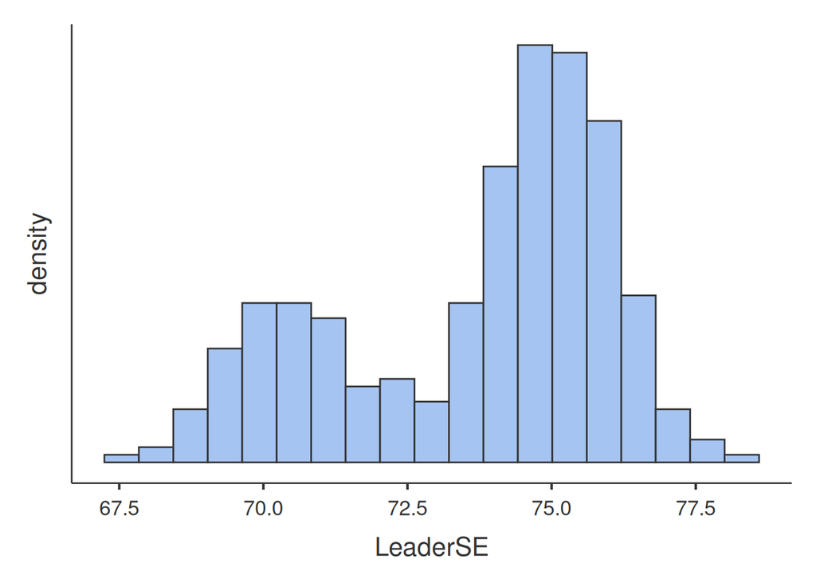

```r
# Get descriptive statistics for the entire sample
desc_lead <- descriptives(dat_lead, vars = c('Class', 'LeaderSE'), hist = TRUE, freq = TRUE, sd = TRUE, se = TRUE, skew = TRUE, kurt = TRUE)

desc_lead
```

```
##
##  DESCRIPTIVES
##
##  Descriptives
##  ──────────────────────────────────────────────
##                           Class    LeaderSE
##  ──────────────────────────────────────────────
##    N                      intro           255
##                           none            107
##    Missing                intro             0
##                           none              0
##    Mean                   intro      75.06000
##                           none       70.44800
##    Std. error mean        intro    0.06575355
##                           none      0.1082745
##    Median                 intro      75.06411
##                           none       70.54574
##    Standard deviation     intro      1.050000
##                           none       1.120000
##    Minimum                intro      71.94892
##                           none       67.65890
##    Maximum                intro      78.41765
##                           none       73.54508
##    Skewness               intro    0.07275128
##                           none      0.1046722
##    Std. error skewness    intro     0.1525009
##                           none      0.2335703
##    Kurtosis               intro     0.1502438
##                           none     -0.2586134
##    Std. error kurtosis    intro     0.3038452
##                           none      0.4631127
##  ──────────────────────────────────────────────
```

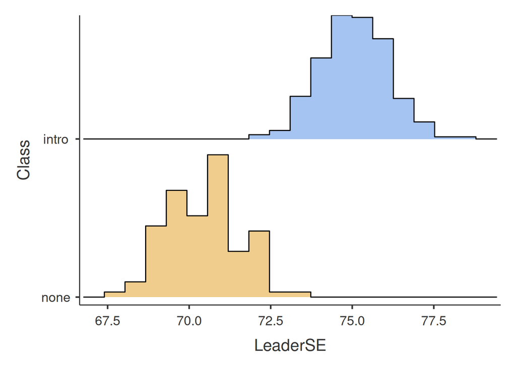

```r
# Get descriptive statistics for each group
groupdesc_lead <- descriptives(dat_lead, vars = c('LeaderSE'), splitBy='Class', hist = TRUE, sd = TRUE, se = TRUE, skew = TRUE, kurt = TRUE)

groupdesc_lead
```

**VISUALIZE YOUR DATA**

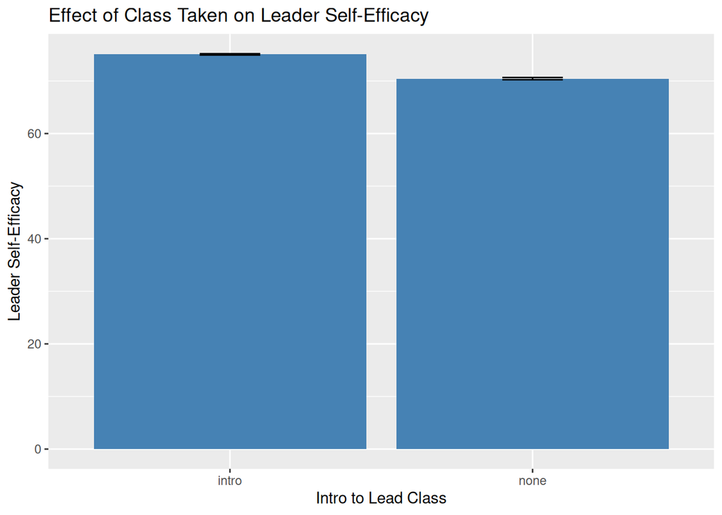

```r
#creating a bar graph
leadbar <- ggplot(dat_lead, aes(Class, LeaderSE))

leadbar + stat_summary(fun = mean, geom = "bar", position = "dodge", fill="steelblue") + stat_summary(fun.data = mean_cl_normal, geom = "errorbar", position = position_dodge(width = 0.90), width = 0.2) + labs(x = "Intro to Lead Class", y = "Leader Self-Efficacy") + ggtitle('Effect of Class Taken on Leader Self-Efficacy')
```

**T TEST**

```r
#vars = outcome variable
jmv::ttestIS(data = dat_lead, vars = 'LeaderSE', group = 'Class', effectSize = TRUE, ci = TRUE, meanDiff = TRUE, desc = TRUE)
```

```
##
##  INDEPENDENT SAMPLES T-TEST
##
##  Independent Samples T-Test
##  ──────────────────────────────────────────────────────────────────────────────────────────────────────────────────────────────────────────────────────────
##                               Statistic    df          p             Mean difference    SE difference    Lower       Upper                    Effect Size
##  ──────────────────────────────────────────────────────────────────────────────────────────────────────────────────────────────────────────────────────────
##    LeaderSE    Student's t     37.38286    360.0000    < .0000001           4.612000        0.1233721    4.369380    4.854620    Cohen's d       4.305908
##  ──────────────────────────────────────────────────────────────────────────────────────────────────────────────────────────────────────────────────────────
##    Note. Hₐ μ <sub>intro</sub> ≠ μ <sub>none</sub>
##
##
##  Group Descriptives
##  ──────────────────────────────────────────────────────────────────────────────
##                Group    N      Mean        Median      SD          SE
##  ──────────────────────────────────────────────────────────────────────────────
##    LeaderSE    intro    255    75.06000    75.06411    1.050000    0.06575355
##                none     107    70.44800    70.54574    1.120000     0.1082745
##  ──────────────────────────────────────────────────────────────────────────────
```

*APA WRITE UP* An independent t-test confirmed that students who took the Intro to Leadership class (*M* = 75.06) had significantly higher leader self-efficacy than students who did not (*M* = 70.45), *t*(360) = 37.38, *p* < .001, *d* = 4.31, 95% CI [4.37,4.85]. There was a large effect of taking the intro class, the mean self-efficacy of the students in the class was over 4 standard deviations higher than that of those who did not.